# FigureYa317RoeDot

**Author(s)**: Xiaofan Lu; Yasi Zhang  
**Reviewer(s)**: Ying Ge  
**Date**: 2025-05-20

# 需求描述

# Requirements Description

基于Ro/e分析对这些细胞亚群进行了组织富集分析，结果观察到肥大细胞和髓系细胞优先分布在动脉粥样硬化核心(AC)部位，而淋巴细胞优先分布在邻近部位。

Tissue enrichment analysis based on Ro/e revealed that mast cells and myeloid cells were predominantly localized in the atherosclerotic core (AC), while lymphocytes were enriched in adjacent regions.

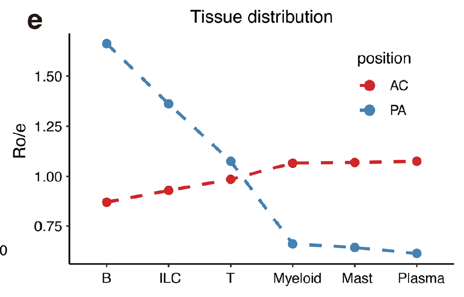

出自：https://bmcbiol.biomedcentral.com/articles/10.1186/s12915-023-01540-2

图1 利用单细胞RNA测序解析动脉粥样硬化的免疫景观 e 通过Ro/e评分估算各细胞类型组织分布情况的折线图

Source: https://bmcbiol.biomedcentral.com/articles/10.1186/s12915-023-01540-2

Fig. 1 Dissection of the immune landscape in atherosclerosis with scRNA-seq. e Line chart showing tissue prevalence for each cell type estimated by Ro/e score

# 应用场景

# Application Scenario

根据单细胞数据，计算细胞比例分布特异度（Ro/e），并绘制折线图

输入：Seurat对象，具有样本来源（Group）和细胞类型（Celltypes）信息

把多组Ro/e绘制成热图，可参考FigureYa312CellPreferencehttps://k.youshop10.com/2Pg4u-pL。

Calculate cell proportion distribution specificity (Ro/e) based on single-cell data and plot a line graph

Input: Seurat object containing sample origin (Group) and cell type (Celltypes) information

Plot the Ro/e values of multiple groups as a heatmap, refer to FigureYa312CellPreferencehttps://k.youshop10.com/2Pg4u-pL for guidance.

# 环境设置

# Environment Setup

使用国内镜像安装包。

Using domestic mirrors for package installation.

```r
options("repos"= c(CRAN="https://mirrors.tuna.tsinghua.edu.cn/CRAN/"))
options(BioC_mirror="http://mirrors.tuna.tsinghua.edu.cn/bioconductor/")
```

# 加载包

# Loading packages

```r
library(Seurat)
# 用于从GEO里的GSE159677_series_matrix.txt.gz文件读取样本信息
# For reading sample information from GSE159677_series_matrix.txt.gz in GEO
library(GEOquery)
```

```r
library(magrittr)
library(plyr)
library(openxlsx)
library(GSVA)

# 用于生成期望频数表(Ro/e计算)
# For generating expected frequency tables (Ro/e calculation)
library(epitools)

library(reshape2)
library(ggplot2)

# 显示英文报错信息
# Show English error messages
Sys.setenv(LANGUAGE = "en")

# 禁止chr转成factor
# Prevent character-to-factor conversion
options(stringsAsFactors = FALSE)
```

# 输入文件

# Input Files

从GEO下载输入数据，https://www.ncbi.nlm.nih.gov/geo/query/acc.cgi?acc=GSE159677。下载Supplementary file表格里的`GSE159677_RAW.tar`，和Download family里的`Series Matrix File(s)`，存放在InputData文件夹里。

Download input data from GEO: https://www.ncbi.nlm.nih.gov/geo/query/acc.cgi?acc=GSE159677. Download `GSE159677_RAW.tar` from the Supplementary files table and `Series Matrix File(s)` from the Download family section, then store them in the InputData folder.

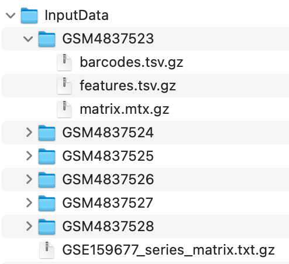

单细胞数据的准备

Preparation of Single-Cell Data

```r
# 单细胞数据的准备
# 目标：生成一个注释好的Seurat对象，以备作图需求
# Seurat对象应包含以下信息:
# 样本分组（group）和细胞类型（Celltypes）
# Preparation of Single-Cell Data
# Objective: Generate an annotated Seurat object for plotting purposes
# The Seurat object should contain the following information:
# Sample grouping (group) and Cell types (Celltypes)

# 设置存放输入数据的路径
# Set input data path
data.path <- file.path("InputData")

# 读取样本信息
# Read sample metadata
sample.info <- getGEO(filename = file.path(data.path,"GSE159677_series_matrix.txt.gz"))
sample.info <- as.data.frame(sample.info)
sample.info$title <- gsub(" scRNA-seq", "", sample.info$title)
sample.info <- data.frame(
  "geo" = sample.info$geo_accession,
  "patient" = gsub("(.+)\ (.+)\ (.+)", "\\1\\2", sample.info$title),
  "group" = gsub("(.+)\ (.+)\ (.+)", "\\3", sample.info$title)
)

# 批量读取表达矩阵
# Batch import expression matrices
samples <- list.dirs("InputData", full.names = T)[-1]
mtx.list <- lapply(samples, function(sample){
  mtx = Read10X(data.dir = sample)
  colnames(mtx) = paste0(substr(basename(sample), 1, 10), colnames(mtx))
  return(mtx)
})
mtx <- do.call(cbind, mtx.list)

# 生成Seurat对象
# Create Seurat object
seu <- CreateSeuratObject(mtx, min.cells = 3, min.features = 200)
seu$Sample <- substr(colnames(seu), 1, 10)
seu$Patient <- mapvalues(x = seu$Sample,
                         from = sample.info$geo, to = sample.info$patient)
seu$Group <- mapvalues(x = seu$Sample,
                       from = sample.info$geo, to = sample.info$group)

# 标准预处理流程
# Standard preprocessing pipeline
seu <- FindVariableFeatures(seu) %>% NormalizeData() %>% ScaleData()
seu <- RunPCA(seu)
seu <- RunUMAP(seu, dims = 1:20)
seu <- FindNeighbors(seu, dims = 1:20) %>% FindClusters(resolution = 0.4)
DimPlot(seu, group.by = "seurat_clusters", label = T)

# 此处使用机器注释（实际情况中应使用手动注释）
# Automated cell type annotation (manual annotation recommended in practice)
marker <- read.xlsx("marker.xlsx")
marker <- split(marker$GeneSymbol, marker$Celltype)
param <- GSVA::gsvaParam(exprData = AverageExpression(seu)[[1]],
                         geneSets = marker)
marker.score <- GSVA::gsva(param)
anno <- data.frame(
  "cluster" = colnames(marker.score),
  "celltype" = rownames(marker.score)[apply(marker.score, 2, which.max)]
)
seu$Celltypes <- mapvalues(x = seu$seurat_clusters,
                           from = anno$cluster, to = anno$celltype)
saveRDS(seu, "seu.rds") # 保存seu对象
```

# 计算Ro/e

# Calculate Ro/e

```r
# 读取Seurat对象
# Read Seurat object
seu <- readRDS("seu.rds")
observe.data <- as.matrix(as.data.frame.matrix(table(seu$Group, seu$Celltypes)))

# 计算Ro/e
# Calculate Ro/e
expected.data <- expected(observe.data)
Ratio <- observe.data/expected.data

# 输出Ro/e表格
# Output Ro/e table
write.table(Ratio, "output_RatioOE.txt",
            sep = "\t", row.names = F, col.names = T, quote = F)
```

# 绘制Ro/e折线图

# Plotting Ro/e line chart

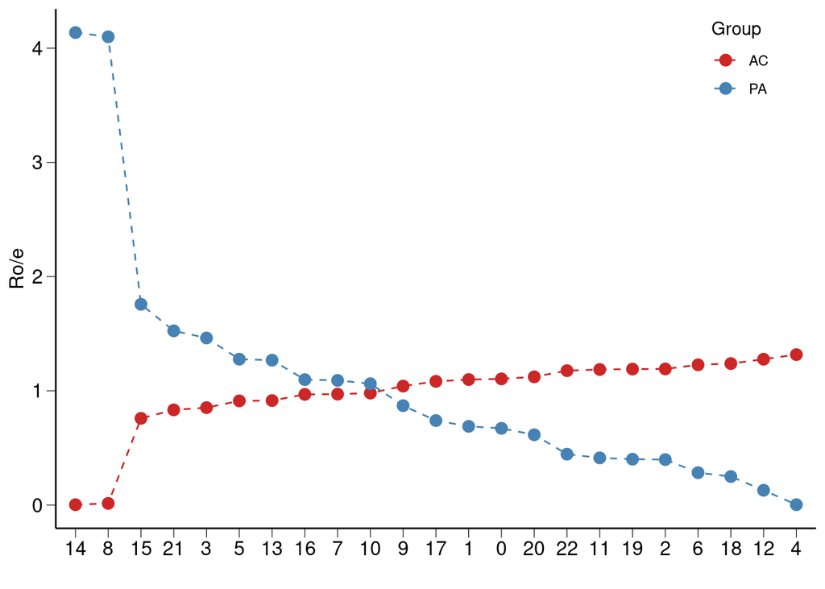

```r
# 生成绘图数据
# Generate plotting data
plot.data <- melt(Ratio)
colnames(plot.data) <- c("Group", "Celltype", "Ratio")
plot.data$Celltype <- factor(as.character(plot.data$Celltype),
                             levels = colnames(Ratio)[order(Ratio[1, ])])

color <- setNames(object = c("#CD2626", "#4682B4"),
                 nm = c("AC", "PA"))

# 画折线图
# Draw line chart
ggplot(plot.data, aes(x = Celltype, y = Ratio, group = Group, color = Group))+
  geom_point(size = 3) +
  geom_line(linetype = "dashed") +
  scale_color_manual(values = color) +
  theme_classic() +
  labs(x = "", y = "Ro/e", fill = "position") +
  theme(axis.text.x = element_text(hjust = 0.5, size = 12, color = "black"),
        axis.title.y = element_text(hjust = 0.5, size = 12, color = "black"),
        axis.text.y = element_text(hjust = 0.5, size = 12, color = "black"),
        axis.ticks = element_line(size = 0.2, color="black"),
        axis.ticks.length = unit(0.2, "cm"),
        panel.background = element_blank(),
        panel.grid = element_blank(),

        # 自己调整，把图例放到空白处
        # Adjust manually to place legend in blank area
        legend.position = c(0.9, 0.9),
        axis.title = element_text(size = 10),
        axis.text = element_text(size = 10))
```

```r
ggsave("Roedot.pdf", width = 5, height = 4)
```

# 会话信息